# cchs: An R Package for Stratified Case-Cohort Studies

## 6 Other issues for the user

Calling `cchs` twice with the same arguments will not necessarily give exactly the same results, which is unusual for estimators that maximize a likelihood or pseudo-likelihood. This happens for two reasons: first, Estimator III involves randomness in the choice of $J_{s(i_j)}$; and second, if there are tied event-times, these are changed in a random way. To get exactly the same results, set the random seed (using `set.seed`) just before the call to `cchs`.

Another approach would be to call `cchs` multiple times, using the `replicate` command, then combine the results, perhaps by using Rubin’s rules (Rubin 1987; Schafer 1999), which are normally used for multiple imputation. With this approach, for each term in the model the coefficient estimate is the mean of the separate estimates, and the variance is the mean of the separate variances plus a term to account for the between-replication variability. It might be worth expressly comparing the within-replication variability (the separate variance estimates) with the between-replication variability (the variability due to the randomness of the estimator). Figure 1 shows the point-estimates and confidence intervals that appear in the previous section, and the quartiles and ranges of the point-estimates produced by 1000 calls to `cchs` with the same arguments. Here, the between-replication variability is small, and very small compared to the within-replication variability.

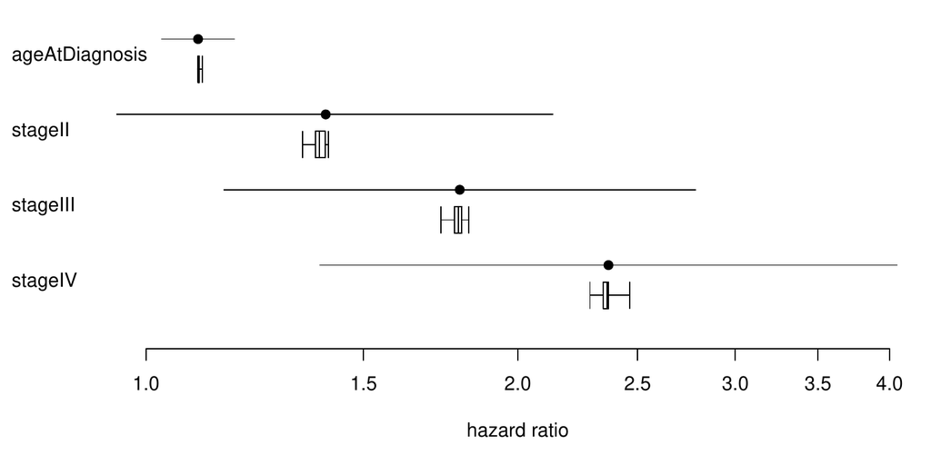

Figure 1: The dots and horizontal lines show the point-estimates and confidence intervals from the output in “5”; this is within-replication variability. The boxes and whiskers show the hazard ratios from 1000 replications of `cchs`, using the dataset and model in the same section; this is between-replication variability. The boxes show the quartiles and the whiskers show the full ranges.

In `coxph`, model formulas can contain certain special terms. Of these, `cchs` allows `offset` terms, but it does not allow `cluster` (for identifying correlated groups of rows), `strata` (for fitting a stratified Cox model), or `tt` (for time-varying covariates). If the data are from a stratified case-cohort study and it is desired to fit a stratified Cox model where the strata in the baseline hazard are the same as the strata for the subcohort-selection, then Prentice’s estimator should be used (Langholz and Jiao 2007b).

All error and warning messages produced by `cchs` are designed to be meaningful. This is achieved by checking the arguments and raising an error if any of them have illegal values, and by adding extra messages to any errors or warnings raised by `model.frame` or `coxph` when they are called internally by `cchs`. The addition of the extra messages results in the call stack, which can be viewed by typing `traceback()`, being longer and more complicated than usual. Therefore if `traceback()` is going to be used to diagnose problems, it is advisable to switch the extra messages off by setting `annotateErrors = FALSE`.

## 7 How `cchs` works

The `cchs` function works differently from the previously published SAS and S-Plus code in several ways, and these novel aspects of its implementation affect the amount of computational time and memory that it uses and enable it to work with much bigger datasets. They also affect the numbers in the output. These issues are discussed here for cautious or curious users who want to know how `cchs` works or compare it with other software for Estimator III.

Functions that calculate estimators for the Cox model with case-cohort data invariably work by manipulating the data or the model-formula in various ways—for example, duplicating rows and changing entry-times, or appending weights to the rows and including the weight in the model-formula—and then passing the data and model-formula to a second model-fitting function (in R, `coxph`) whose original purpose is to fit the Cox model with the standard estimator. The manipulation is done in such a way that when the second function attempts to maximize the partial likelihood, what it actually maximizes is the pseudo-likelihood for the case-cohort estimator. The second function returns the estimates of the regression coefficients and their covariance matrix, and the top-level function usually then makes adjustments to the covariance matrix.

This method works because the standard partial likelihood and the various pseudo-likelihoods all have similar forms. They have the same number of multiplicative terms, one for each case, and the same values in the numerators (apart from multiplicative factors, which are easy to deal with). The only differences are the sets of participants who appear in the denominators and, for some pseudo-likelihoods, multiplicative factors in the denominators. These sets are dealt with by duplicating or excluding rows and changing entry- and exit-times, and any multiplicative factors are dealt with by using an offset term in the model-formula.

For Estimator III, the manipulations are rather complicated because of the swapping. The `cchs` function manipulates the data as follows:

**Step 1**

Define a small number $\epsilon$, which is smaller than any of the differences between consecutive event-times.

**Step 2**

For each $i_j \notin C$, change the entry-time to $t_j - \epsilon$, where $t_j$ is the exit-time.

**Step 3**

For each stratum $s$:

**Step 3.1**

Choose a random participant $J_s$ from $C \cap s$. Denote the entry-time for $J_s$ by $t_{0s}$ and the exit-time by $t_{1s}$.

**Step 3.2**

Let $U_s = \{t_j: i_j \in s, i_j \notin C, t_{0s} < t_j \leq t_{1s} \}$. Sort $U_s$ into increasing order as $u_{s(1)},\dots, u_{s(|U_s|)}$.

**Step 3.3**

Replace $J_s$’s row by $|U_s|+1$ new rows with variables as follows.

- Row 1: entry-time $t_{0s}$, exit-time $u_{s(1)}-\epsilon$, event-indicator zero.
- Row 2: entry-time $u_{s(1)}$, exit-time $u_{s(2)}-\epsilon$, event-indicator zero.
- …
- Row $|U_s|$: entry-time $u_{s(|U_s|-1)}$, exit-time $u_{s(|U_s|)}-\epsilon$, event-indicator zero.
- Row $|U_s|+1$: entry-time $u_{s(|U_s|)}$, exit-time $t_{1s}$, event-indicator as in the original row.

These steps are best understood by referring to the earlier definition of $R(t_j)$ and bearing in mind that `coxph` takes a row’s at-risk time to be the half-open interval, (entry-time, exit-time]. The purpose of step 1 is to choose $\epsilon$ to be sufficiently small that steps 2 and 3 do not have any unintended effects on other terms in the pseudo-likelihood. Step 2 has the effect of removing the non-subcohort cases from $R(t_j)$, except for $i_j$ itself, which is not removed. Step 3 makes the further changes to $R(t_j)$ that are needed if $i_j \notin C$. Note that it deals with one $J_s$, not one $i_j$, at a time. Step 3.1 chooses $J_s$. Step 3.2 defines $U_s$ to be the event-times that lie in the range of $J_s$’s at-risk time and correspond to non-subcohort cases in $s$. Step 3.3 excises a short stretch of at-risk time from $J_s$ at each time in $U_s$ by splitting $J_s$’s row into multiple rows with separate stretches of at-risk time.

The effect of step 3 is to remove $J_{s(i_j)}$ from $R(t_j)$ when $i_j \notin C$, as required by the definition of $R(t_j)$. For a non-subcohort case in $s$ whose event-time is not in $U_s$, it makes no difference whether $J_{s(i_j)}$ is in $R(t_j)$ or not, because $Y_{J_{s(i_j)}}(t_j)$ is zero; so for such cases this manipulation is not necessary.

One other change to the data is needed. An extra column is created that contains $-\log \alpha_{s(k)}$ for participant $k$, and this is included as an offset term in the model-formula that `cchs` passes to `coxph`. This has the effect of inserting the $\alpha_{s(k)} ^ {-1}$ factors that are needed in the denominators.

## 8 The calculation of the covariance matrix

The `cchs` function uses an asymptotic covariance estimator, as recommended by Jiao (2001). Internally, after it manipulates the data and calls `coxph`, the final step is to adjust the covariance matrix. This is done by using the matrix of “dfbeta” residuals, $D$, produced by `residuals.coxph`; $d_{ij}$ is the change in the estimate of regression coefficient $j$ when row $i$ is dropped from the data (or an approximation of that change). The covariance matrix is adjusted by adding $\sum_s m_s (1 - \alpha_s) \operatorname{Cov} D_{C \cap s}$, where $m_s=|C \cap s|$, $D_{C \cap s}$ is the rows of $D$ that correspond to $C \cap s$, and $\operatorname{Cov} D_{C \cap s}$ is the empirical covariance matrix $D_{C \cap s}^\top D_{C \cap s} / (m_s - 1)$.

This adjustment corresponds to Equation (17) in Borgan et al. (2000). The use of $D$ is based on the formula for the adjustment to the covariance matrix with unstratified case-cohort data, which appears on page 102 of Therneau and Li (1999) and as Equation (5) in Langholz and Jiao (2007b). There is a small discrepancy between the formulas in these two publications. To explain this, let $D_C$ be the rows of $D$ that correspond to $C$ and let $\alpha = m / n$ be the sampling fraction, where $m$ is the size of the subcohort and $n$ is the size of the cohort. According to Therneau and Li, the quantity to add to the covariance matrix is $(1 - \alpha) D_C^\top D_C$, but according to Langholz and Jiao it is $\frac{m(n - m)}{n} \operatorname{Cov} D_C=(1-\alpha) \frac{m}{m - 1} D_C^\top D_C$. These expressions differ by a factor of $m / (m - 1)$, which is unimportant if $m$ is large, but makes a difference if $m$ is small. The `cchs` function does the calculation in the same way as Langholz and Jiao and Cologne et al. (2012).

## 9 How the SAS code and S-Plus code work

The previously published SAS and S-Plus code-fragments for Estimator III manipulate the data in a completely different way from `cchs`:

**Step 1**

Define a small number $\epsilon$, which is smaller than any of the differences between consecutive event-times.

**Step 2**

For each $i_j \notin C$, change the entry-time to $t_j - \epsilon$.

**Step 3**

Replace the dataset with a new dataset that is constructed as follows. For each $i_j$:

**Step 3.1**

Make one copy of all the rows.

**Step 3.2**

Drop those of the new rows that are not at risk at $t_j$.

**Step 3.1**

For all rows, set the entry-time to $t_j - \epsilon$ and the exit-time to $t_j$, and set the event-indicator to $1$ for $i_j$ and $0$ for the other rows.

**Step 4**

For each $i_j \notin C$, choose a random participant $J_{s(i_j)}$ from $C \cap s(i_j)$ and remove the row that contains $J_{s(i_j)}$ and has exit-time $t_j$.

Step 3 radically changes the dataset and greatly increases its size. The result of the manipulations is that when the data is passed to `coxph` in S-Plus or `proc phreg` in SAS, each row corresponds to exactly one additive term in the numerator or denominator of one multiplicative term of the pseudo-likelihood. The $\alpha_{s(k)} ^ {-1}$ terms and the adjustment to the covariance matrix are dealt with in the same way as in `cchs`.

The advantage of this method is that steps 3 and 4 are relatively simple—the “swapping” in step 4 just consists of choosing and removing a single row each time. The disadvantages are that if the original dataset is medium or large in size then this method uses a gigantic amount of memory and requires `coxph` to deal with a gigantic dataset. For step 3.1, the S-Plus code creates a data frame that contains one row for every combination of a case and a participant. In EPIC-CVD, a typical dataset that was supplied to an investigator contained about $31,000$ participants, of whom $14,000$ were cases, and this took up about 4.4MB as a binary file. So the data frame created by step 3 would have $31,000 \times 14,000 \approx 434$ million rows and take up about 62GB. This is too big for a desktop computer to store in memory, and even after some rows are removed in step 4, the data frame would be far too big for `coxph` to process in a reasonable amount of time.

In contrast, when `cchs` is used on the same dataset, the manipulated dataset has fewer than $31,000 + 14,000 = 45,000$ rows. This $45,000$ was calculated by supposing that for every case an extra row is created, whereas in reality some cases are in the subcohort and it is likely that some “swapper” rows are not at risk at the relevant event-times, and for these no extra rows are created, so the true number of rows in the manipulated dataset is less than $45,000$.

The manipulation of the data by the SAS and S-Plus code can be regarded as maximal, in the sense that each row ultimately corresponds to a single additive term in a single multiplicative term of the pseudo-likelihood. The manipulation by `cchs` can be regarded as minimal, since it makes only the manipulations that are strictly necessary in order for `coxph` to calculate the correct pseudo-likelihood, and it leaves the data with the smallest possible number of rows.

## 10 Obscure aspects of the calculation

Three obscure issues arise in calculating Estimator III. Under normal circumstances users of `cchs` can ignore these, but for development or testing it may be necessary to understand these issues or, as described below, set the relevant logical arguments to different values.

The first issue has to do with the `dropNeverAtRiskRows` argument, which determines whether rows should be dropped if their at-risk time does not contain any of the event-times. The dropped rows make no difference to the regression coefficients output by `cchs`, but they do affect the covariance-estimates and confidence intervals, because of the approximation that `residuals.coxph` uses to calculates the dfbeta residuals. The SAS code and S-Plus code drop these rows (in step 3.2), but Borgan et al. (2000) and Langholz and Jiao (2007b) make no mention of this issue. In `cchs`, `dropNeverAtRiskRows` is `TRUE` by default but can be set to `FALSE` if desired.

The second issue has to do with the `dropSubcohEventsDfbeta` argument. When the adjustment to the covariance matrix is calculated, the correct way is to use all the rows of the matrix of dfbeta residuals that correspond to subcohort members. The SAS code and S-Plus code both omit the rows that correspond to subcohort cases at their event-times, presumably because this makes the code simpler and is unlikely to change the output greatly. By default, `cchs` calculates the adjustment to the covariance matrix in the strictly correct way. But if `dropSubcohEventsDfbeta` is `TRUE`, then it calculates the adjustment in the same way as the SAS and S-Plus code, as follows. For each $i_j \in C$, it splits that row of the data at $t_j - \epsilon$ and replaces it with two rows; the first row has entry-time $t_{0i_j}$, exit-time $t_j - \epsilon$, and event-indicator $0$; and the second row has entry-time $t_j - \epsilon$, exit-time $t_j$, and event-indicator $1$. When calculating the adjustment to the covariance matrix, `cchs` excludes the row of the dfbeta residuals that corresponds to the second of these two rows.

The third issue is that the “swapper” $J_{s(i_j)}$ is supposed to be selected once for each stratum (see Section 3 of (Borgan et al. 2000)), but the SAS and S-Plus both select it once for each case. The `cchs` function selects the swapper correctly. It has no logical argument to specify how the swapper should be selected, since it manipulates the data in a completely different way from the SAS and S-Plus code.

## 11 Discussion

In case-cohort studies, stratified selection of the subcohort seems to be common (Sharp et al. 2014), so there are likely to be plenty of investigations where `cchs` may be useful. The way in which `cchs` manipulates the data makes it faster and more computationally efficient than the previously published SAS and S-Plus code. The three obscure issues described in the previous section should not greatly affect most analyses, but will make a difference with small datasets.

## 12 Acknowledgments

The author would like to thank Michael Sweeting for his helpful comments. This work was funded by the UK Medical Research Council (G0800270), the British Heart Foundation (SP/09/002), the UK National Institute for Health Research (Cambridge Biomedical Research Centre), the European Research Council (268834), and the European Commission Framework Programme 7 (HEALTH-F2-2012-279233).

### 12.1 Supplementary materials

Supplementary materials are available in addition to this article. It can be downloaded at RJ-2018-012.zip

### 12.2 CRAN packages used

cchs, survival, survey, NestedCohort

### 12.3 CRAN Task Views implied by cited packages

ClinicalTrials, Econometrics, OfficialStatistics, Survival

S. Bingham and E. Riboli. Diet and cancer—the European Prospective Investigation into Cancer and Nutrition. *Nature Reviews Cancer*, 4(3): 206–215, 2004. URL https://doi.org/10.1038/nrc1298.

Ørnulf Borgan, B. Langholz, S. O. Samuelsen, L. Goldstein and J. Pogoda. Exposure stratified case–cohort designs. *Lifetime Data Analysis*, 6(1): 39–58, 2000. URL https://doi.org/10.1023/A:1009661900674.

N. E. Breslow, T. Lumley, C. M. Ballantyne, L. E. Chambless and M. Kulich. Improved Horvitz–Thompson estimation of model parameters from two-phase stratified samples: Applications in epidemiology. *Statistics in Biosciences*, 1(1): 32–49, 2009a. URL https://doi.org/10.1007/s12561-009-9001-6.

N. E. Breslow, T. Lumley, C. M. Ballantyne, L. E. Chambless and M. Kulich. Using the whole cohort in the analysis of case–cohort data. *American Journal of Epidemiology*, 169(11): 1398–1405, 2009b. URL https://doi.org/10.1093/aje/kwp055.

J. Cologne, D. L. Preston, K. Imai, M. Misumi, K. Yoshida, T. Hayashi and K. Nakachi. Conventional case–cohort design and analysis for studies of interaction. *International Journal of Epidemiology*, 41(4): 1174–1186, 2012. URL https://doi.org/10.1093/ije/dys102.

D. R. Cox. Regression models and life-tables. *Journal of the Royal Statistical Society B*, 34(2): 187–220, 1972. URL https://www.jstor.org/stable/2985181.

G. J. D’Angio, N. Breslow, J. B. Beckwith, A. Evans, E. Baum, A. Delorimier, D. Fernbach, E. Hrabovsky, B. Jones, P. Kelalis, et al. Treatment of Wilms’ tumor: Results of the third National Wilms’ Tumor Study. *Cancer*, 64(2): 349–360, 1989. URL https://doi.org/10.1002/1097-0142(19890715)64:2<349::AID-CNCR2820640202>3.0.CO;2-Q.

J. Danesh, R. Saracci, G. Berglund, E. Feskens, K. Overvad, S. Panico, S. Thompson, A. Fournier, F. Clavel-Chapelon, M. Canonico, et al. EPIC-Heart: The cardiovascular component of a prospective study of nutritional, lifestyle and biological factors in 520,000 middle-aged participants from 10 European countries. *European Journal of Epidemiology*, 22(2): 129–141, 2007. URL https://doi.org/10.1007/s10654-006-9096-8.

V. P. Godambe. An optimum property of regular maximum likelihood estimation. *The Annals of Mathematical Statistics*, 31(4): 1208–1211, 1960. URL https://doi.org/10.1214/aoms/1177705693.

V. P. Godambe. Conditional likelihood and unconditional optimum estimating equations. *Biometrika*, 63(2): 277–284, 1976. URL https://doi.org/10.1093/biomet/63.2.277.

R. J. Gray. Weighted analyses for cohort sampling designs. *Lifetime Data Analysis*, 15(1): 24–40, 2009. URL https://doi.org/10.1007/s10985-008-9095-z.

D. M. Green, N. E. Breslow, J. B. Beckwith, J. Z. Finklestein, P. E. Grundym, P. R. Thomas, T. Kim, S. J. Shochat, G. M. Haase, M. L. Ritchey, et al. Comparison between single-dose and divided-dose administration of dactinomycin and doxorubicin for patients with Wilms’ tumor: A report from the National Wilms’ Tumor Study Group. *Journal of Clinical Oncology*, 16(1): 237–256, 1998. URL https://doi.org/10.1200/JCO.1998.16.1.237.

R. R. Huxley, F. L. Lopez, R. F. MacLehose, J. H. Eckfeldt, D. Couper, C. Leiendecker-Foster, R. C. Hoogeveen, L. Y. Chen, E. Z. Soliman, S. K. Agarwal, et al. Novel association between plasma matrix metalloproteinase-9 and risk of incident atrial fibrillation in a case-cohort study: The Atherosclerosis Risk in Communities study. *PLOS One*, 8(3): 1–8, 2013. URL https://doi.org/10.1371/journal.pone.0059052.

InterAct Consortium. Design and cohort description of the InterAct project: An examination of the interaction of genetic and lifestyle factors on the incidence of type 2 diabetes in the EPIC study. *Diabetologia*, 54(9): 2272–2282, 2011. URL https://doi.org/10.1007/s00125-011-2182-9.

J. Jiao. Comparison of variance estimators in case–cohort studies. 2001. URL http://digitallibrary.usc.edu/cdm/ref/collection/p15799coll16/id/242761.

E. Jones. *cchs: Cox model for case–cohort data with stratified subcohort-selection.* 2017. URL https://cran.r-project.org/package=cchs. R package version 0.4.0.

E. Jones, M. J. Sweeting, S. J. Sharp and S. G. Thompson. A method making fewer assumptions gave the most reliable estimates of exposure–outcome associations in stratified case–cohort studies. *Journal of Clinical Epidemiology*, 68(12): 1397–1405, 2015. URL https://doi.org/10.1016/j.jclinepi.2015.04.007.

S. P. Juraschek, G. P. S. Shantha, A. Y. Chu, E. R. Miller III, E. Guallar, R. C. Hoogeveen, C. M. Ballantyne, F. L. Brancati, M. I. Schmidt, J. S. Pankow, et al. Lactate and risk of incident diabetes in a case-cohort of the Atherosclerosis Risk in Communities (ARIC) study. *PLOS One*, 8(1): 1–7, 2013. URL https://doi.org/10.1371/journal.pone.0055113.

H. A. Katki and S. D. Mark. Survival analysis for cohorts with missing covariate information. *R News*, 8(1): 14–19, 2008. URL https://www.r-project.org/doc/Rnews/Rnews_2008-1.pdf\#section*.31.

J. P. Kim, W. Lu, T. Sit and Z. Ying. A unified approach to semiparametric transformation models under general biased sampling schemes. *Journal of the American Statistical Association*, 108(501): 217–227, 2013. URL https://doi.org/10.1080/01621459.2012.746073.

M. Kulich and D. Lin. Improving the efficiency of relative-risk estimation in case–cohort studies. *Journal of the American Statistical Association*, 99(467): 832–844, 2004. URL https://doi.org/10.1198/016214504000000584.

M. M. Lamb, M. D. Simpson, J. Seifert, F. W. Scott, M. Rewers and J. M. Norris. The association between IgG4 antibodies to dietary factors, islet autoimmunity and type 1 diabetes: The diabetes autoimmunity study in the young. *PLOS One*, 8(2): 1–7, 2013. URL https://doi.org/10.1371/journal.pone.0057936.

B. Langholz and J. Jiao. Case–cohort computation. 2007a.

B. Langholz and J. Jiao. Computational methods for case–cohort studies. *Computational Statistics & Data Analysis*, 51(8): 3737–3748, 2007b. URL https://doi.org/10.1016/j.csda.2006.12.028.

B. Lindsay. Conditional score functions: Some optimality results. *Biometrika*, 69(3): 503–512, 1982. URL https://doi.org/10.1093/biomet/69.3.503.

D. Liu, T. Cai and Y. Zheng. Evaluating the predictive value of biomarkers with stratified case-cohort design. *Biometrics*, 68(4): 1219–1227, 2012. URL https://doi.org/10.1111/j.1541-0420.2012.01787.x.

T. Lumley. Analysis of complex survey samples. *Journal of Statistical Software*, 9(8): 1–19, 2004. URL https://doi.org/10.18637/jss.v009.i08.

T. Lumley. *survey: Analysis of complex survey samples.* 2017a. URL https://cran.r-project.org/package=survey. R package version 3.32-1.

T. Lumley. *Two-phase designs in epidemiology.* 2017b. URL https://cran.r-project.org/web/packages/survey/vignettes/epi.pdf.

S. D. Mark and H. A. Katki. Specifying and implementing nonparametric and semiparametric survival estimators in two-stage (nested) cohort studies with missing case data. *Journal of the American Statistical Association*, 101(474): 460–471, 2006. URL https://doi.org/10.1198/016214505000000952.

R. Payne, M. Neykov, M. K. Jensen and T. Cai. Kernel machine testing for risk prediction with stratified case cohort studies. *Biometrics*, 72(2): 372–381, 2016. URL https://doi.org/10.1111/biom.12452.

R. L. Prentice. A case–cohort design for epidemiologic cohort studies and disease prevention trials. *Biometrika*, 73(1): 1–11, 1986. URL https://doi.org/10.1093/biomet/73.1.1.

D. B. Rubin. *Multiple imputation for nonresponse in surveys.* New York: John Wiley & Sons, 1987. URL https://doi.org/10.1002/9780470316696.

S. O. Samuelsen, H. Ånestad and A. Skrondal. Stratified case–cohort analysis of general cohort sampling designs. Department of Mathematics, University of Oslo. 2006. URL https://www.duo.uio.no/handle/10852/10351.

S. O. Samuelsen, H. Ånestad and A. Skrondal. Stratified case–cohort analysis of general cohort sampling designs. *Scandinavian Journal of Statistics*, 34(1): 103–119, 2007. URL https://doi.org/10.1111/j.1467-9469.2006.00552.x.

SAS Institute Inc. *SAS software, version 8.* Cary, NC, 1999. URL http://www.sas.com/.

J. L. Schafer. Multiple imputation: A primer. *Statistical Methods in Medical Research*, 8(1): 3–15, 1999. URL https://doi.org/10.1177/096228029900800102.

T. A. Severini. Frequency properties of inferences based on an integrated likelihood function. *Statistica Sinica*, 21(1): 433–447, 2011. URL https://www.jstor.org/stable/24309279.

S. J. Sharp, M. Poulaliou, S. G. Thompson, I. R. White and A. M. Wood. A review of published analyses of case–cohort studies and recommendations for future reporting. *PLOS One*, 9(6): e101176, 2014. URL https://doi.org/10.1371/journal.pone.0101176.

T. M. Therneau. *survival: A package for survival analysis in S.* 2017. URL https://cran.r-project.org/package=survival. R package version 2.41-3.

T. M. Therneau and P. M. Grambsch. *Modeling survival data: Extending the Cox model.* New York: Springer-Verlag, 2000.

T. M. Therneau and H. Li. Computing the Cox model for case–cohort designs. *Lifetime Data Analysis*, 5(2): 99–112, 1999. URL https://doi.org/10.1023/A:1009691327335.

Tibco Software Inc. *S-Plus software, version 8.* Palo Alto, CA, 2007. URL http://www.tibco.com/.

Y. Yan, H. Zhou and J. Cai. Improving efficiency of parameter estimation in case-cohort studies with multivariate failure time data. *Biometrics*, 73(3): 1042–1052, 2017. URL https://doi.org/10.1111/biom.12657.

D. Zeng and D. Y. Lin. Maximum likelihood estimation in semiparametric regression models with censored data. *Journal of the Royal Statistical Society B*, 69(4): 507–564, 2007. URL https://doi.org/10.1111/j.1369-7412.2007.00606.x.